# Credit Data Analysis

10/13/2019

## Introduction

Statement of Problem:

Financial crisis of 2008-2009 has exposed credit institutions approving loan applicants who ultimately default on their loans.

The credit branch has to reassess the way they evaluate applicants for bad credit risk. The stakeholder need for data analytics is crucial because of the impact it will have on applicants and the financial institution. Predictive analysis will help determine the risk based on several variables such as duration of credit and checking account status.

## Data Overview

- 31 variables
- Based on a 1000 past credit applicants
- Variable types consist of numerical, categorical, and binary.
- Target variable is “DEFAULT” (defaulted on a loan)

## Topics

- Pilot Evaluation
- Plan Modification
- Plan Implementation and Results
- Conclusions and Implications
- Recommendations

## Pilot Evaluation

## Successes and Challenges of Pilot

- Challenges
  - Some of the challenges from the pilot was making use of the information given as well as seeking other outside sources to expand on the data available.
  - Understanding variable importance for analysis +converting numeric variables to categorical
- Successes
  - Having the data produce results
- Areas of concern
  - Are results from the pilot run valid?

## Pilot Evaluation Continued…

- The pilot run of the credit data indicates there is a 66% chance the random forest model can predict correctly which applicants will default if given a loan.
- After evaluating the random forest model’s performance from pilot, it is shown that the model has a 78% accuracy based on the area under the curve. Which is above the bench mark curve.

## Pilot Evaluation Continued…

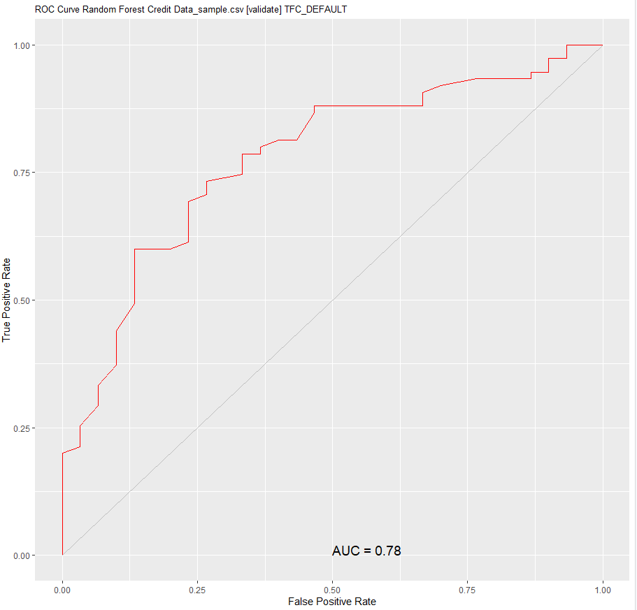

## Plan Modification

## Data Analytic Architecture Pattern

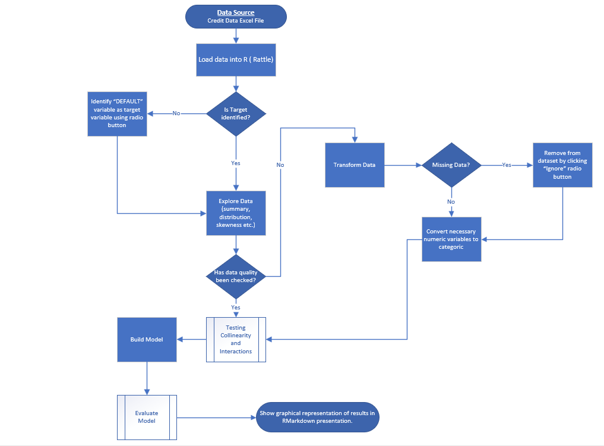

## Data Analytic Architecture Pattern Continued…

- Data quality
- Integrity
- Security of information

## Data Quality

Data quality can be categorized based on the usability, reliability, and completeness of the dataset.Missing data was evaluated through the Rattle interface within the R program. The target variable and identifier variable was clearly identified upon loading data. The quality of the data did not seem to be an issue from the initial loading of data.

## Integrity

The integrity of the data was brought into question after transforming the necessary variables from numeric to categorical.

## Security of Information

Security is very important especially in the wake of data breaches occurrances on the rise. Protecting the applicants personal information should be the organizations top priority.

## Plan Implementation and Results

## Plan Implementation and Results Continued…

Link to [Implementation and Results](https://github.com/michelle0803/myDATrepo.git)

## Plan Implementation and Results Continued…

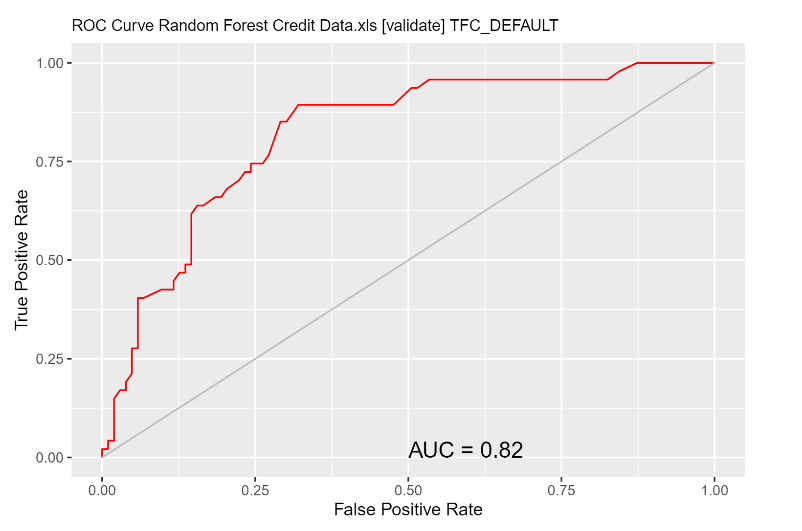

## Plan Implementation and Results Continued…

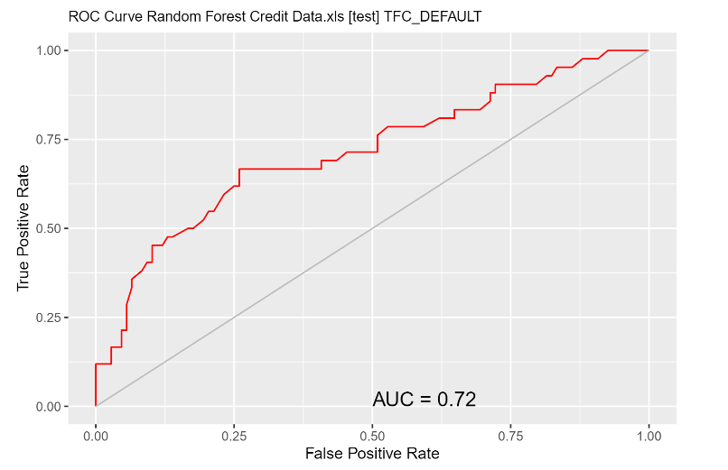

## Conclusions and Implications

In conclusion, based on the model performance being 82% accuracy for the validation data set and 72% for the test data set the random forest model is a good fit for predicting which applicants will default on their loan. Having this knowledge has the potential to cut costs dramatically for the financial institution. This will also eliminate the repeat of the 2008-2009 financial crisis by making it easier to determine defaults in potential applicants.

## Recommendations

## Recommendations Continued…

Opportunities for future and alternative uses:

- Internal audits
- Marketing optimization
- Collections
- Fraud detection

## References

Atherton, D. (2005). What is… CRISP-DM? Direct Response, , 19. Retrieved from http://ezproxy.snhu.edu/login?qurl=https%3A%2F%2Fsearch.proquest.com%2Fdocview%2F224774623%3Faccountid%3D3783

Descriptive, Predictive, and Prescriptive Analytics Explained. (2018, November 28). Retrieved from https://halobi.com/blog/descriptive-predictive-and-prescriptive-analytics-explained/

Kaur, S. (2018, November 30). Understanding Credit Risk Analytics. Retrieved from https://analyticstraining.com/understanding-credit-risk-analytics/

Kosakowski, P. (2019, May 08). The Fall of the Market in the Fall of 2008. Retrieved from https://www.investopedia.com/articles/economics/09/subprime-market-2008.asp

Pierre, R. (2018, July 08). An Intro to Data Science for Credit Risk Modelling. Retrieved from https://towardsdatascience.com/an-intro-to-data-science-for-credit-risk-modelling-57935805a911

Pierre, R. (2018, July 15). A Gentle Introduction to Credit Risk Modeling with Data Science - Part 2. Retrieved from https://towardsdatascience.com/a-gentle-introduction-to-credit-risk-modeling-with-data-science-part-2-d7b87806c9df

SNHU. (2019). DAT-650-Q2049 Advanced Data Analytics 19TW4. Retrieved June 9, 2019, from Learning Module Two: https://learn.snhu.edu/d2l/le/content/212734/Home?itemIdentifier=D2L.LE.Content.ContentObject.ModuleCO-4880198

Williams, G. J. (2013). Data mining with Rattle and R: The art of excavating data for knowledge discovery. New York: Springer.

M, Swapna. (2019, February 21). Data Privacy & User Protection in Banking & Finance. Retrieved from https://medium.com/datadriveninvestor/data-privacy-user-protection-in-banking-finance-3ba53717d99b

The Best Cybersecurity Strategies for Banks and Financial Organizations. (2018, October 18). Retrieved from https://www.goanywhere.com/blog/2018/10/18/best-data-security-strategies-banking-financing-organizations

TSR - The Software Report. (2019, December 18). Retrieved from https://www.thesoftwarereport.com/top-25-cybersecurity-companies-of-2018/

1. Other Primary Data Sources. Retrieved from https://www.chicagofed.org/banking/financial-institution-reports/other-primary-data-sources

Chan, C. (2018, July 5). What is a ROC Curve and How to Interpret It. Retrieved from https://www.displayr.com/what-is-a-roc-curve-how-to-interpret-it/

Das, A. (2013, November 15). Credit scoring using Rattle and R. Retrieved from https://www.slideshare.net/AyanDas6/credit-scoring-using-rattle

Pearson Product-Moment Correlation. (n.d.). Retrieved from https://statistics.laerd.com/statistical-guides/pearson-correlation-coefficient-statistical-guide.php